# Google Data Analytics Capstone

Ganesh Rajasekar

2025-11-07

# Initialize packages

```r
library(tidyverse)
library(data.table)
```

# Read in Data

## Cancer Surgeries by Hospital

### General Next Step for Data Cleaning: Create Key of County based on OSHPD ID (4th and 5th number in ID)

```r
county_code <- c(
  "01","02","03","04","05","06","07","08","09","10",
  "11","12","13","14","15","16","17","18","19","20",
  "21","22","23","24","25","26","27","28","29","30",
  "31","32","33","34","35","36","37","38","39","40",
  "41","42","43","44","45","46","47","48","49","50",
  "51","52","53","54","55","56","57","58"
)

county_name <- c(
  "ALAMEDA","ALPINE","AMADOR","BUTTE","CALAVERAS","COLUSA","CONTRA COSTA",
  "DEL NORTE","EL DORADO","FRESNO","GLENN","HUMBOLDT","IMPERIAL","INYO",
  "KERN","KINGS","LAKE","LASSEN","LOS ANGELES","MADERA","MARIN","MARIPOSA",
  "MENDOCINO","MERCED","MODOC","MONO","MONTEREY","NAPA","NEVADA","ORANGE",
  "PLACER","PLUMAS","RIVERSIDE","SACRAMENTO","SAN BENITO","SAN BERNARDINO",
  "SAN DIEGO","SAN FRANCISCO","SAN JOAQUIN","SAN LUIS OBISPO","SAN MATEO",
  "SANTA BARBARA","SANTA CLARA","SANTA CRUZ","SHASTA","SIERRA","SISKIYOU",
  "SOLANO","SONOMA","STANISLAUS","SUTTER","TEHAMA","TRINITY","TULARE",
  "TUOLUMNE","VENTURA","YOLO","YUBA"
)

county_dt <- data.table(
  county_code = county_code,
  county_name = county_name
)

county_dt
```

| county_code | county_name |
| --- | --- |
| 01 | ALAMEDA |
| 02 | ALPINE |
| 03 | AMADOR |
| 04 | BUTTE |
| 05 | CALAVERAS |
| 06 | COLUSA |
| 07 | CONTRA COSTA |
| 08 | DEL NORTE |
| 09 | EL DORADO |
| 10 | FRESNO |

[output cut: 48 more lines]

| county_code <chr> | county_name <chr> |  |  |  |
| --- | --- | --- | --- | --- |
| 01 | ALAMEDA |  |  |  |
| 02 | ALPINE |  |  |  |
| 03 | AMADOR |  |  |  |
| 04 | BUTTE |  |  |  |
| 05 | CALAVERAS |  |  |  |
| 06 | COLUSA |  |  |  |
| 07 | CONTRA COSTA |  |  |  |
| 08 | DEL NORTE |  |  |  |
| 09 | EL DORADO |  |  |  |
| 10 | FRESNO |  |  |  |

### Data Cleaning Next Steps for Cancer Surgeries: Aggregate all data at the county level by year

```r
#acquire county code based on substring (first two numbers in OSHPD ID)
cancsurg_2[,county_code:=substr(OSHPDID,4,5)]

#merge to county name lookup table
cancsurg_3<-merge.data.table(cancsurg_2,county_dt,by="county_code")
# automatically removes any irrelevant rows (e.g. statewide rows)
```

## ED utilization

```r
setwd("C:/Users/ganes/Desktop/Google Capstone Project Github Track/Emergency Room Visits")

edvisits<-fread("encounters-by-facility_2012-2024_20250807.csv")

#keep entries from 2020-2024 only
edvisits_2<-edvisits[year%in%c(2020:2024)]
edvisits_alt<-edvisits%>%filter(year>=2020&year<=2024)

#county name already present in data, no changes needed
```

## Primary Care Utilization

### Note: for these Excel sheets, the first few rows between the column names and data were removed for easy reading into R

```r
setwd("C:/Users/ganes/Desktop/Google Capstone Project Github Track/Annual Primary Care Utilization 2020-2024/cleaned data")

#cleaned by removing rows 2-5 from the "Resp" pages.

filestoread<-list.files(getwd())

pcutil_20<-readxl::read_xlsx(filestoread[1],sheet="Page 1-8")
pcutil_21<-readxl::read_xlsx(filestoread[2],sheet="Page 1-8")
pcutil_22<-readxl::read_xlsx(filestoread[3],sheet="Page 1-8")
pcutil_23<-readxl::read_xlsx(filestoread[4],sheet="Page 1-8")
pcutil_24<-readxl::read_xlsx(filestoread[5],sheet="Page 1-8")

setDT(pcutil_20)
setDT(pcutil_21)
setDT(pcutil_22)
setDT(pcutil_23)
setDT(pcutil_24)
```

### Data Cleaning for Primary Care Data: Use # of Encounters by Primary care Providers.

```r
#example
summary(pcutil_23$TOT_ENC_BY_PRIM_CARE_PROVIDER_FOR_ENC)
```

```
##    Min. 1st Qu.  Median    Mean 3rd Qu.    Max.    NA's
##       2    5489   13163   23365   28879  296507      73
```

```r
#keep year, county, facility name, oshpd_id, and tot_enc in each dataset (labelled relevant)

#Calculate PCP encounters by manually adding different variables mentioned in PCP Utilization Pivot Table


pcutil_20_rel<-pcutil_20[,c("COUNTY","FAC_NAME","FAC_NO","EVAL_MANAGEMENT_ESTABLISHED_PAT_ENC","EVAL_MANAGEMENT_NEW_PAT_ENC","HOS_RELATED_SERV_ENC","MED_SPEC_SERV_ENC","PREV_MED_INFANT_CHILD_ADOL_ENC","PREV_MED_ADULT_ENC","COUNSELING_ENC","INTEGUMENTARY_SYS_ENC","MATERNITY_CARE_DELIVERY_ENC","PATHOLOGY_LAB_ENC")]
pcutil_21_rel<-pcutil_21[,c("COUNTY","FAC_NAME","FAC_NO","EVAL_MANAGEMENT_ESTABLISHED_PAT_ENC","EVAL_MANAGEMENT_NEW_PAT_ENC","HOS_RELATED_SERV_ENC","MED_SPEC_SERV_ENC","PREV_MED_INFANT_CHILD_ADOL_ENC","PREV_MED_ADULT_ENC","COUNSELING_ENC","INTEGUMENTARY_SYS_ENC","MATERNITY_CARE_DELIVERY_ENC","PATHOLOGY_LAB_ENC")]
pcutil_22_rel<-pcutil_22[,c("COUNTY","FAC_NAME","FAC_NO","EVAL_MANAGEMENT_ESTABLISHED_PAT_ENC","EVAL_MANAGEMENT_NEW_PAT_ENC","HOS_RELATED_SERV_ENC","MED_SPEC_SERV_ENC","PREV_MED_INFANT_CHILD_ADOL_ENC","PREV_MED_ADULT_ENC","COUNSELING_ENC","INTEGUMENTARY_SYS_ENC","MATERNITY_CARE_DELIVERY_ENC","PATHOLOGY_LAB_ENC")]
pcutil_23_rel<-pcutil_23[,c("COUNTY","FAC_NAME","FAC_NO","EVAL_MANAGEMENT_ESTABLISHED_PAT_ENC","EVAL_MANAGEMENT_NEW_PAT_ENC","HOS_RELATED_SERV_ENC","MED_SPEC_SERV_ENC","PREV_MED_INFANT_CHILD_ADOL_ENC","PREV_MED_ADULT_ENC","COUNSELING_ENC","INTEGUMENTARY_SYS_ENC","MATERNITY_CARE_DELIVERY_ENC","PATHOLOGY_LAB_ENC")]
pcutil_24_rel<-pcutil_24[,c("COUNTY","FAC_NAME","FAC_NO","EVAL_MANAGEMENT_ESTABLISHED_PAT_ENC","EVAL_MANAGEMENT_NEW_PAT_ENC","HOS_RELATED_SERV_ENC","MED_SPEC_SERV_ENC","PREV_MED_INFANT_CHILD_ADOL_ENC","PREV_MED_ADULT_ENC","COUNSELING_ENC","INTEGUMENTARY_SYS_ENC","MATERNITY_CARE_DELIVERY_ENC","PATHOLOGY_LAB_ENC")]
varstosum<-c("EVAL_MANAGEMENT_ESTABLISHED_PAT_ENC","EVAL_MANAGEMENT_NEW_PAT_ENC","HOS_RELATED_SERV_ENC","MED_SPEC_SERV_ENC","PREV_MED_INFANT_CHILD_ADOL_ENC","PREV_MED_ADULT_ENC","COUNSELING_ENC","INTEGUMENTARY_SYS_ENC","MATERNITY_CARE_DELIVERY_ENC","PATHOLOGY_LAB_ENC")

pcutil_20_rel[,YEAR:=2020]
pcutil_21_rel[,YEAR:=2021]
pcutil_22_rel[,YEAR:=2022]
pcutil_23_rel[,YEAR:=2023]
pcutil_24_rel[,YEAR:=2024]

pcutil<-rbind(pcutil_20_rel,pcutil_21_rel,pcutil_22_rel,pcutil_23_rel,pcutil_24_rel)
setDT(pcutil)
#sum all variables
pcutil[,TOT_ENC_BY_PRIM_CARE_PROVIDER_FOR_ENC:=rowSums(.SD,na.rm=T),.SDcols=varstosum]
```

# Aggregate and Merge all Datasets Together

## First Step: Aggregate Counts of Surgeries by County, Year, Facility ID, and Facility Name

```r
surgs_county_fac_year<-cancsurg_3[,.(surg_count=sum(`# of Cases`)),by=c("Year","County","OSHPDID","hospital")]
```

## Second Step: Aggregate Counts of ED Visits by County, Year and then by County,Facility,Year

```r
edvisits_county_fac_year<-edvisits_2[,.(ed_count=sum(count)),by=c("year","county_name","oshpd_id","facility_name")]
```

## Third Step: Aggregate Counts of PCP Vistis by County, Year and then by Facility,Year

```r
pcp_county_fac_year<-pcutil[,.(pcp_count=sum(TOT_ENC_BY_PRIM_CARE_PROVIDER_FOR_ENC)),by=c("YEAR","COUNTY","FAC_NO","FAC_NAME")]
```

# Next Step: Harmonize all the variable names in the datasets above and export as a csv for use in Tableau

## Check sparsity of data at facility level when merging all data to each other (debug)

### Standardize variable names

```r
#standardize Year, County, and fac_name across datasets
setnames(edvisits_county_fac_year,"year","Year")
setnames(edvisits_county_fac_year,"county_name","County")
setnames(pcp_county_fac_year,"COUNTY","County")
setnames(pcp_county_fac_year,"YEAR","Year")

setnames(edvisits_county_fac_year,"facility_name","fac_name")
setnames(pcp_county_fac_year,"FAC_NAME","fac_name")
setnames(pcp_county_fac_year,"FAC_NO","oshpd_id")
pcp_county_fac_year[,oshpd_id:=as.integer(oshpd_id)]
setnames(surgs_county_fac_year,"hospital","fac_name")
setnames(surgs_county_fac_year,"OSHPDID","oshpd_id")
#Standardize case of facility name
surgs_county_fac_year[,`:=`(fac_name=toupper(fac_name),County=str_to_title(County))]
edvisits_county_fac_year[,County:=str_to_title(County)]

#for cancer surgery dataset, fix the name of a few counties that are cut off in original data
surgs_county_fac_year[,County:=fcase(County=="San Bernardi","San Bernardino",
                                         County=="San Francisc", "San Francisco",
                                         County=="San Luis Obi", "San Luis Obispo",
                                         County=="Santa Barbar", "Santa Barbara",
                                         default=County)]
```

```r
# Code from ChatGPT, code to uniformly clean facility names and county names with slightly different spellings. This would have been very tedious to check manually.
clean_keys_dt <- function(dt) {

  # create a copy if you don't want in-place edits:
  # dt <- copy(dt)

  # standardize fac_name and County in-place
  dt[
    ,
    fac_name := fac_name |>
      # remove things like "n = 1305," at the start
      str_remove("^n\\s*=\\s*\\d+,\\s*") |>
      # drop punctuation we don't want to compare on
      str_replace_all("[^A-Za-z0-9 ]", " ") |>
      # collapse multiple spaces
      str_squish() |>
      # uppercase for reliable joins
      str_to_upper()
  ]

  dt[
    ,
    County := County |>
      # drop trailing "County"
      str_replace("(?i)\\s+county$", "") |>
      # trim spaces
      str_squish() |>
      # title case (Alameda, San Mateo, Los Angeles)
      str_to_title()
  ]

  # ensure Year is consistent
  if ("Year" %in% names(dt)) {
    dt[, Year := as.integer(Year)]
  }

  return(dt)
}

pcp_county_fac_year<- clean_keys_dt(pcp_county_fac_year)
edvisits_county_fac_year<- clean_keys_dt(edvisits_county_fac_year)
surgs_county_fac_year <- clean_keys_dt(surgs_county_fac_year)
```

### Re-create County-aggregated data with cleaned variables

```r
surgs_county_year<-surgs_county_fac_year[,.(surg_count=sum(surg_count,na.rm=T)),by=c("Year","County")]
pcp_county_year<-pcp_county_fac_year[,.(pcp_count=sum(pcp_count,na.rm=T)),by=c("Year","County")]
edvisits_county_year<-edvisits_county_fac_year[,.(ed_count=sum(ed_count,na.rm=T)),by=c("Year","County")]

#merge together
df_list<-list(edvisits_county_year,pcp_county_year,surgs_county_year)
spe_full<-Reduce(function(x,y) merge(x,y,by=c("Year","County"),all=T),df_list)
spe_full<-spe_full[!is.na(County)]

#save spe_full as dataset while facility-level surgery dataset is separately stored for future reference
write.csv(spe_full,"C:/Users/ganes/Downloads/countyagg_data.csv") # This dataset goes to Tableau.

write.csv(surgs_county_fac_year,"C:/Users/ganes/Downloads/facilityagg_data.csv")
```

## Check Overall Distribution and Missingness of Relevant Values by County

### Check Missing County Info by Year for Cancer Surgeries

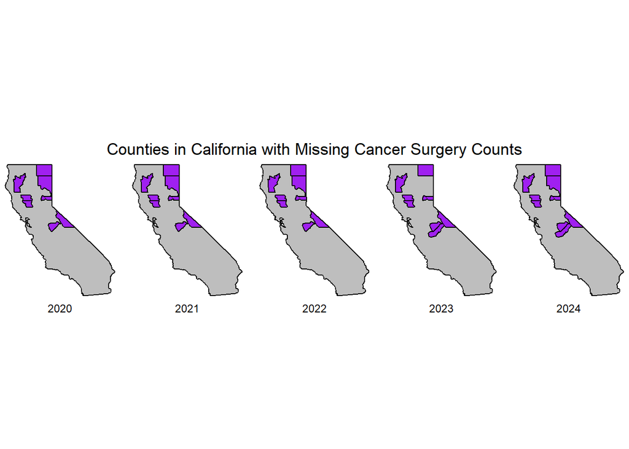

```r
#create dataset with missing counties only (and dummy variable "Miss" to identify counties on map)
miss_surg<-spe_full[is.na(surg_count),.(County),by="Year"][,.(County,Year,Miss=1)]

#create map of California counties

  #base CA map
  california<-map_data("state")%>%filter(region%in%"california")

  ca_base<-ggplot(california,mapping=aes(x=long,y=lat,group=group))+coord_fixed(1.3)+geom_polygon(color="black",fill="gray")

  #CA counties data
  counties<-map_data("county")%>%filter(region=="california")%>%mutate(County=str_to_title(subregion))
  #merge missing county info to county data for all years
  counties_byyear<-merge(miss_surg,counties,by="County",all.y=TRUE)%>%mutate(Miss=ifelse(is.na(Miss),0,1))


  #Map overall graph
  ca_base+geom_polygon(data=counties_byyear[!is.na(Year)],aes(fill=factor(Miss)),color="black")+geom_polygon(color="black",fill=NA)+facet_grid(~Year,switch="x")+theme_void()+theme(legend.position="none",plot.title = element_text(hjust = 0.5))+scale_fill_manual(values=c("purple","gray"))+labs(title="Counties in California with Missing Cancer Surgery Counts")
```

### List of Counties Missing Cancer Surgeries by Year

```r
#transpose with pseudo-row number
miss_surg[, row := seq_len(.N), by = Year]
wide_missing <- dcast(
  miss_surg,
  row ~ Year,
  value.var = "County",
  fill=""
)[, row := NULL]

knitr::kable(wide_missing)
```

| 2020 | 2021 | 2022 | 2023 | 2024 |
| --- | --- | --- | --- | --- |
| Colusa | Colusa | Colusa | Colusa | Colusa |
| Glenn | Glenn | Glenn | Glenn | Glenn |
| Lassen | Lassen | Lassen | Madera | Lassen |
| Mariposa | Mariposa | Mariposa | Mariposa | Madera |
| Modoc | Modoc | Modoc | Modoc | Mariposa |
| Mono | Mono | Mono | Mono | Modoc |
| Sierra | Sierra | Sierra | Sierra | Mono |
| Trinity | Trinity | Trinity | Trinity | Sierra |
|  |  |  |  | Trinity |

### Check Missing County Info by Year for PCP Utilization

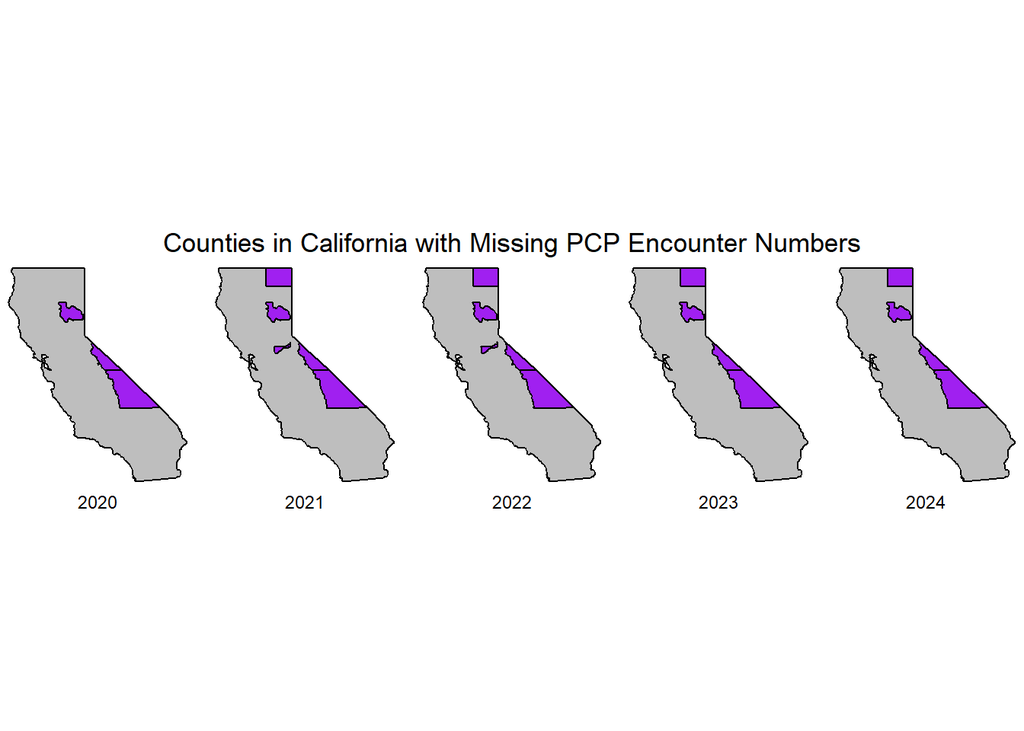

```r
#create dataset with missing counties only (and dummy variable "Miss" to identify counties on map)
miss_pcp<-spe_full[is.na(pcp_count),.(County),by="Year"][,.(County,Year,Miss=1)]

#create map of California counties

  #base CA map
  california<-map_data("state")%>%filter(region%in%"california")

  ca_base<-ggplot(california,mapping=aes(x=long,y=lat,group=group))+coord_fixed(1.3)+geom_polygon(color="black",fill="gray")

  #CA counties data
  counties<-map_data("county")%>%filter(region=="california")%>%mutate(County=str_to_title(subregion))
  #merge missing county info to county data for all years
  counties_byyear<-merge(miss_pcp,counties,by="County",all.y=TRUE)%>%mutate(Miss=ifelse(is.na(Miss),0,1))


  #Map overall graph
  ca_base+geom_polygon(data=counties_byyear[!is.na(Year)],aes(fill=factor(Miss)),color="black")+geom_polygon(color="black",fill=NA)+facet_grid(~Year,switch="x")+theme_void()+theme(legend.position="none",plot.title = element_text(hjust = 0.5))+scale_fill_manual(values=c("purple","gray"))+labs(title="Counties in California with Missing PCP Encounter Numbers")
```

### List of Counties Missing PCP Encounters by Year

```r
#transpose with pseudo-row number
miss_pcp[, row := seq_len(.N), by = Year]
wide_missing <- dcast(
  miss_pcp,
  row ~ Year,
  value.var = "County",
  fill=""
)[, row := NULL]

knitr::kable(wide_missing)
```

| 2020 | 2021 | 2022 | 2023 | 2024 |
| --- | --- | --- | --- | --- |
| Inyo | Amador | Amador | Inyo | Inyo |
| Mono | Inyo | Inyo | Modoc | Modoc |
| Plumas | Modoc | Modoc | Mono | Mono |
|  | Mono | Mono | Plumas | Plumas |
|  | Plumas | Plumas |  |  |

### Check Missing County Info by Year for ED Utilization

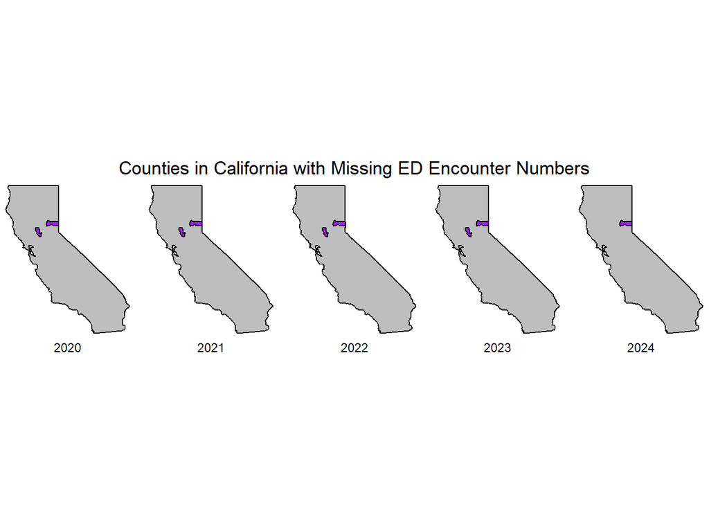

```r
#create dataset with missing counties only (and dummy variable "Miss" to identify counties on map)
miss_ed<-spe_full[is.na(ed_count),.(County),by="Year"][,.(County,Year,Miss=1)]

#create map of California counties

  #base CA map
  california<-map_data("state")%>%filter(region%in%"california")

  ca_base<-ggplot(california,mapping=aes(x=long,y=lat,group=group))+coord_fixed(1.3)+geom_polygon(color="black",fill="gray")

  #CA counties data
  counties<-map_data("county")%>%filter(region=="california")%>%mutate(County=str_to_title(subregion))
  #merge missing county info to county data for all years
  counties_byyear<-merge(miss_ed,counties,by="County",all.y=TRUE)%>%mutate(Miss=ifelse(is.na(Miss),0,1))


  #Map overall graph
  ca_base+geom_polygon(data=counties_byyear[!is.na(Year)],aes(fill=factor(Miss)),color="black")+geom_polygon(color="black",fill=NA)+facet_grid(~Year,switch="x")+theme_void()+theme(legend.position="none",plot.title = element_text(hjust = 0.5))+scale_fill_manual(values=c("purple","gray"))+labs(title="Counties in California with Missing ED Encounter Numbers")
```

```r
#transpose with pseudo-row number
miss_ed[, row := seq_len(.N), by = Year]
wide_missing <- dcast(
  miss_ed,
  row ~ Year,
  value.var = "County",
  fill=""
)[, row := NULL]

knitr::kable(wide_missing)
```

| 2020 | 2021 | 2022 | 2023 | 2024 |
| --- | --- | --- | --- | --- |
| Sierra | Sierra | Sierra | Sierra | Sierra |
| Sutter | Sutter | Sutter | Sutter |  |

# Final Step prior to sending data to Tableau: Create BoxPlot of all Surgeries, ED Visits, and PCP Visits and check for any inconsistencies or general trends by County

## Box Plots

#Cancer Surgeries among all of CA’s Counties by Year

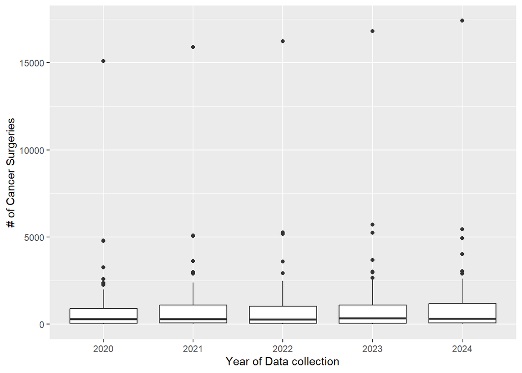

## Distribution of Cancer Surgery Count by Year

```r
surg_count_graph %>%
  group_by(Year) %>%
  summarize(
    min    = min(surg_count, na.rm = TRUE),
    q1     = quantile(surg_count, 0.25, na.rm = TRUE),
    median = median(surg_count, na.rm = TRUE),
    q3     = quantile(surg_count, 0.75, na.rm = TRUE),
    max    = max(surg_count, na.rm = TRUE)
  )
```

| Year | min | q1 | median | q3 | max |
| --- | --- | --- | --- | --- | --- |
| 2020 | 2 | 65.0 | 289 | 900.00 | 15101 |
| 2021 | 7 | 71.0 | 300 | 1111.00 | 15889 |
| 2022 | 4 | 60.0 | 283 | 1037.00 | 16238 |
| 2023 | 2 | 62.0 | 355 | 1095.00 | 16820 |
| 2024 | 2 | 67.5 | 314 | 1195.75 | 17407 |

| Year <int> | min <int> | q1 <dbl> | median <dbl> | q3 <dbl> | max <int> |
| --- | --- | --- | --- | --- | --- |
| 2020 | 2 | 65.0 | 289 | 900.00 | 15101 |
| 2021 | 7 | 71.0 | 300 | 1111.00 | 15889 |
| 2022 | 4 | 60.0 | 283 | 1037.00 | 16238 |
| 2023 | 2 | 62.0 | 355 | 1095.00 | 16820 |
| 2024 | 2 | 67.5 | 314 | 1195.75 | 17407 |

5 rows

#Check Outliers and Extreme Outliers

```r
surg_count_graph[surg_count>2500]
```

| Year | County | surg_count |
| --- | --- | --- |
| 2020 | Los Angeles | 15101 |
| 2020 | Orange | 4776 |
| 2020 | Sacramento | 2599 |
| 2020 | San Diego | 4804 |
| 2020 | Santa Clara | 3273 |
| 2021 | Los Angeles | 15889 |
| 2021 | Orange | 5073 |
| 2021 | Sacramento | 3003 |
| 2021 | San Diego | 5086 |
| 2021 | San Francisco | 2904 |

[output cut: 23 more lines]

| Year <int> | County <chr> | surg_count <int> |  |  |
| --- | --- | --- | --- | --- |
| 2020 | Los Angeles | 15101 |  |  |
| 2020 | Orange | 4776 |  |  |
| 2020 | Sacramento | 2599 |  |  |
| 2020 | San Diego | 4804 |  |  |
| 2020 | Santa Clara | 3273 |  |  |
| 2021 | Los Angeles | 15889 |  |  |
| 2021 | Orange | 5073 |  |  |
| 2021 | Sacramento | 3003 |  |  |
| 2021 | San Diego | 5086 |  |  |
| 2021 | San Francisco | 2904 |  |  |

```r
surg_count_graph[surg_count>15000]
```

| Year | County | surg_count |
| --- | --- | --- |
| 2020 | Los Angeles | 15101 |
| 2021 | Los Angeles | 15889 |
| 2022 | Los Angeles | 16238 |
| 2023 | Los Angeles | 16820 |
| 2024 | Los Angeles | 17407 |

| Year <int> | County <chr> | surg_count <int> |  |  |
| --- | --- | --- | --- | --- |
| 2020 | Los Angeles | 15101 |  |  |
| 2021 | Los Angeles | 15889 |  |  |
| 2022 | Los Angeles | 16238 |  |  |
| 2023 | Los Angeles | 16820 |  |  |
| 2024 | Los Angeles | 17407 |  |  |

5 rows

# Check Graphs with Extreme Outliers Removed

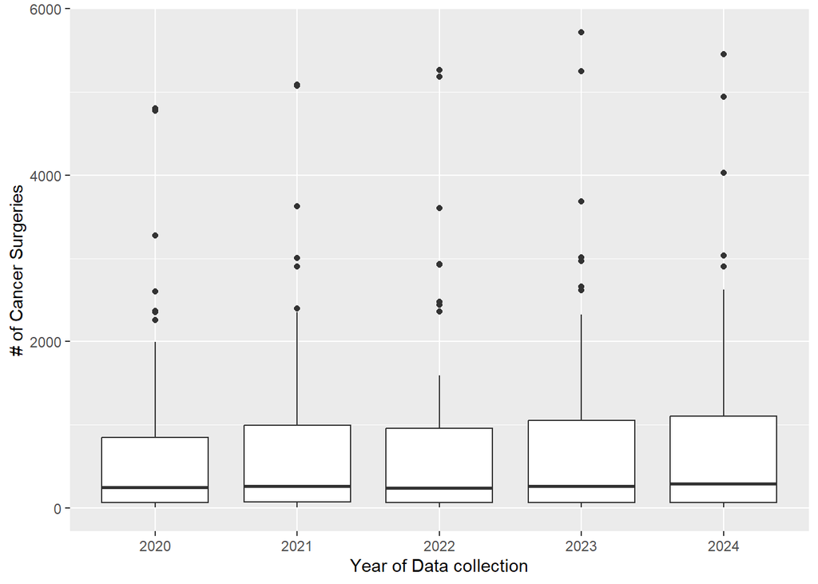

#ED Visits among all of CA’s Counties by Year

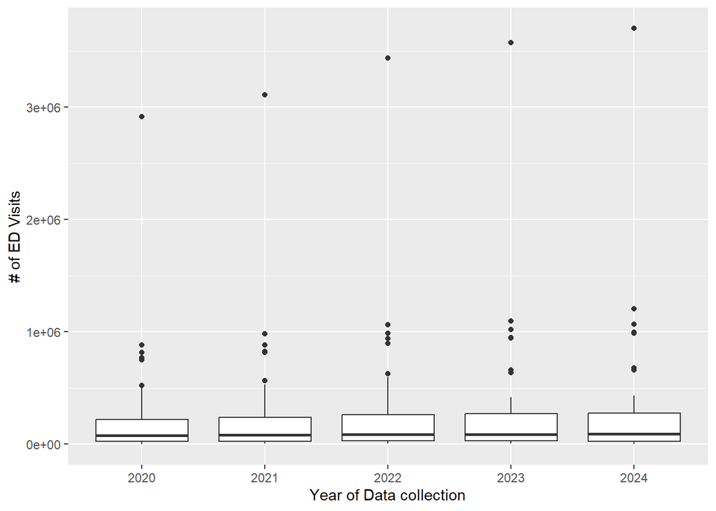

## Distribution of ED Encounters by Year

```r
ed_count_graph %>%
  group_by(Year) %>%
  summarize(
    min    = min(ed_count, na.rm = TRUE),
    q1     = quantile(ed_count, 0.25, na.rm = TRUE),
    median = median(ed_count, na.rm = TRUE),
    q3     = quantile(ed_count, 0.75, na.rm = TRUE),
    max    = max(ed_count, na.rm = TRUE)
  )
```

| Year | min | q1 | median | q3 | max |
| --- | --- | --- | --- | --- | --- |
| 2020 | 3617 | 23915.5 | 77040.0 | 217489.5 | 2915294 |
| 2021 | 4517 | 26454.5 | 84102.0 | 237639.5 | 3108955 |
| 2022 | 4438 | 29020.5 | 86705.0 | 263948.0 | 3436491 |
| 2023 | 4622 | 29301.5 | 87636.0 | 270261.5 | 3574946 |
| 2024 | 0 | 26804.5 | 92225.5 | 274647.5 | 3702644 |

| Year <int> | min <int> | q1 <dbl> | median <dbl> | q3 <dbl> | max <int> |
| --- | --- | --- | --- | --- | --- |
| 2020 | 3617 | 23915.5 | 77040.0 | 217489.5 | 2915294 |
| 2021 | 4517 | 26454.5 | 84102.0 | 237639.5 | 3108955 |
| 2022 | 4438 | 29020.5 | 86705.0 | 263948.0 | 3436491 |
| 2023 | 4622 | 29301.5 | 87636.0 | 270261.5 | 3574946 |
| 2024 | 0 | 26804.5 | 92225.5 | 274647.5 | 3702644 |

5 rows

# Check Outliers and Extreme Outliers

```r
ed_count_graph[ed_count>500000]
```

| Year | County | ed_count |
| --- | --- | --- |
| 2020 | Alameda | 501539 |
| 2020 | Los Angeles | 2915294 |
| 2020 | Orange | 816178 |
| 2020 | Riverside | 752496 |
| 2020 | Sacramento | 521168 |
| 2020 | San Bernardino | 768901 |
| 2020 | San Diego | 882188 |
| 2021 | Alameda | 530095 |
| 2021 | Los Angeles | 3108955 |
| 2021 | Orange | 884294 |

[output cut: 29 more lines]

| Year <int> | County <chr> | ed_count <int> |  |  |
| --- | --- | --- | --- | --- |
| 2020 | Alameda | 501539 |  |  |
| 2020 | Los Angeles | 2915294 |  |  |
| 2020 | Orange | 816178 |  |  |
| 2020 | Riverside | 752496 |  |  |
| 2020 | Sacramento | 521168 |  |  |
| 2020 | San Bernardino | 768901 |  |  |
| 2020 | San Diego | 882188 |  |  |
| 2021 | Alameda | 530095 |  |  |
| 2021 | Los Angeles | 3108955 |  |  |
| 2021 | Orange | 884294 |  |  |

```r
ed_count_graph[ed_count>2000000]
```

| Year | County | ed_count |
| --- | --- | --- |
| 2020 | Los Angeles | 2915294 |
| 2021 | Los Angeles | 3108955 |
| 2022 | Los Angeles | 3436491 |
| 2023 | Los Angeles | 3574946 |
| 2024 | Los Angeles | 3702644 |

| Year <int> | County <chr> | ed_count <int> |  |  |
| --- | --- | --- | --- | --- |
| 2020 | Los Angeles | 2915294 |  |  |
| 2021 | Los Angeles | 3108955 |  |  |
| 2022 | Los Angeles | 3436491 |  |  |
| 2023 | Los Angeles | 3574946 |  |  |
| 2024 | Los Angeles | 3702644 |  |  |

5 rows

# Check Graphs with Extreme Outliers Removed

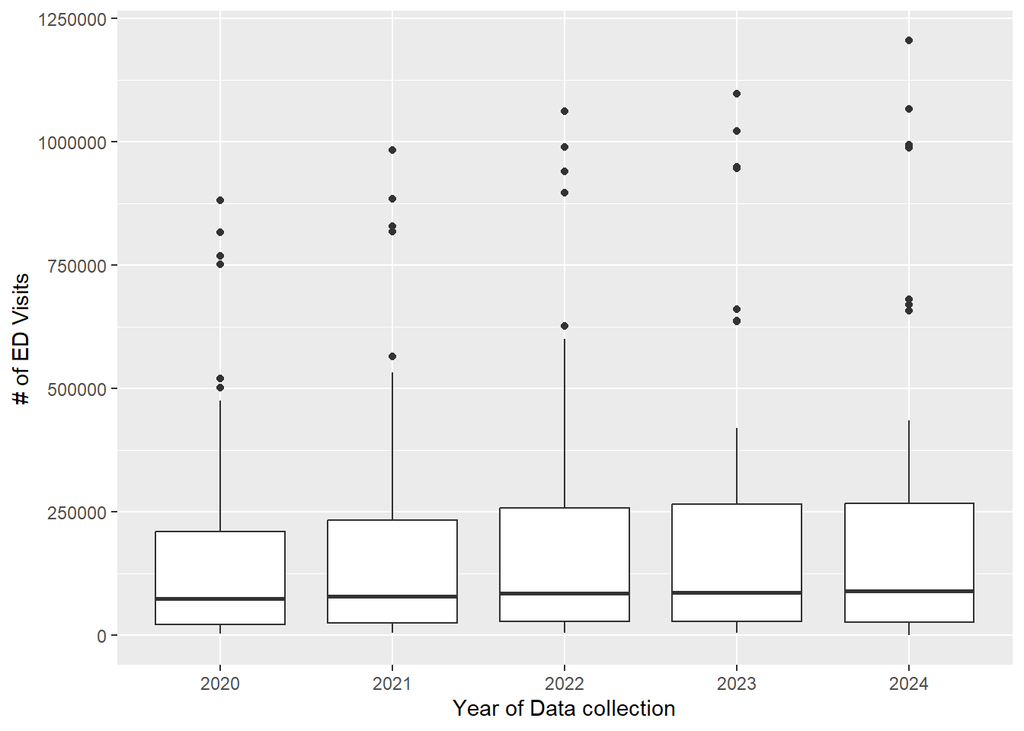

# PCP Encounters among all of CA’s Counties by Year

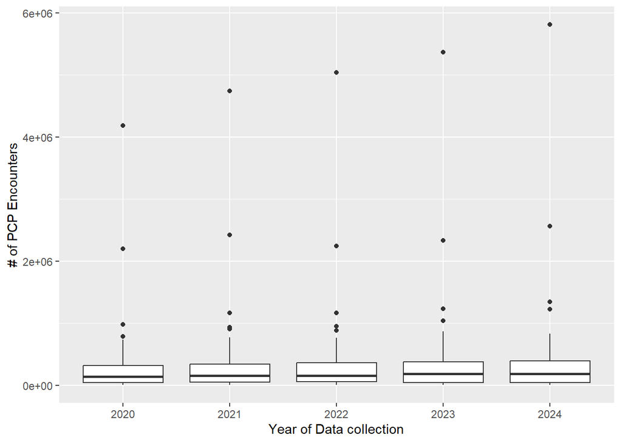

## Distribution of PCP Encounters by Year

```r
pcp_count_graph %>%
  group_by(Year) %>%
  summarize(
    min    = min(pcp_count, na.rm = TRUE),
    q1     = quantile(pcp_count, 0.25, na.rm = TRUE),
    median = median(pcp_count, na.rm = TRUE),
    q3     = quantile(pcp_count, 0.75, na.rm = TRUE),
    max    = max(pcp_count, na.rm = TRUE)
  )
```

| Year | min | q1 | median | q3 | max |
| --- | --- | --- | --- | --- | --- |
| 2020 | 1161 | 41111.00 | 138708.0 | 319170.5 | 4186846 |
| 2021 | 2571 | 50141.25 | 154850.5 | 338749.2 | 4741862 |
| 2022 | 5493 | 52686.00 | 154941.0 | 357856.8 | 5037389 |
| 2023 | 4259 | 39174.00 | 183750.0 | 375170.0 | 5369985 |
| 2024 | 1688 | 43896.00 | 185044.0 | 393252.0 | 5812977 |

| Year <int> | min <dbl> | q1 <dbl> | median <dbl> | q3 <dbl> | max <dbl> |
| --- | --- | --- | --- | --- | --- |
| 2020 | 1161 | 41111.00 | 138708.0 | 319170.5 | 4186846 |
| 2021 | 2571 | 50141.25 | 154850.5 | 338749.2 | 4741862 |
| 2022 | 5493 | 52686.00 | 154941.0 | 357856.8 | 5037389 |
| 2023 | 4259 | 39174.00 | 183750.0 | 375170.0 | 5369985 |
| 2024 | 1688 | 43896.00 | 185044.0 | 393252.0 | 5812977 |

5 rows

# Check Outliers

```r
pcp_count_graph[pcp_count>1000000]
```

| Year | County | pcp_count |
| --- | --- | --- |
| 2020 | Los Angeles | 4186846 |
| 2020 | San Diego | 2199968 |
| 2021 | Fresno | 1163907 |
| 2021 | Los Angeles | 4741862 |
| 2021 | San Diego | 2424804 |
| 2022 | Fresno | 1162810 |
| 2022 | Los Angeles | 5037389 |
| 2022 | San Diego | 2245710 |
| 2023 | Fresno | 1232879 |
| 2023 | Los Angeles | 5369985 |

[output cut: 6 more lines]

| Year <int> | County <chr> | pcp_count <dbl> |  |  |
| --- | --- | --- | --- | --- |
| 2020 | Los Angeles | 4186846 |  |  |
| 2020 | San Diego | 2199968 |  |  |
| 2021 | Fresno | 1163907 |  |  |
| 2021 | Los Angeles | 4741862 |  |  |
| 2021 | San Diego | 2424804 |  |  |
| 2022 | Fresno | 1162810 |  |  |
| 2022 | Los Angeles | 5037389 |  |  |
| 2022 | San Diego | 2245710 |  |  |
| 2023 | Fresno | 1232879 |  |  |
| 2023 | Los Angeles | 5369985 |  |  |

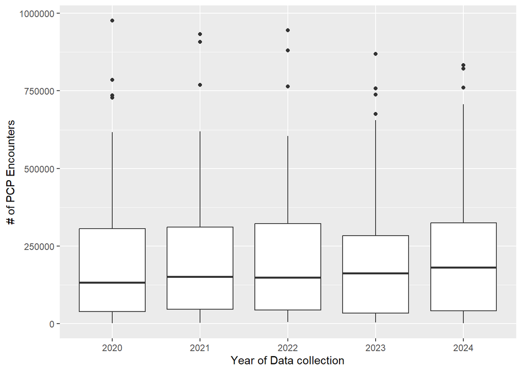